Denali Therapeutics · Confidential · Medical Monitoring Report

# DNLI-I-0001 Medical Monitoring Report

DNL126 (ETV:SGSH-BioM) · MPS IIIA (Sanfilippo Syndrome Type A) · March 2026

Data Cut Date

2026-03-20

MLM Safety Lab

2026MAR20

IRT / PROD Transfer

2026MAR20

Report Generated

2026-04-12 (AI-Generated)

20

Treated Subjects

4

Cohorts

4

Sites

12,216

Lab Records

**Safety-Focused Report.** This report covers safety laboratory data and dosing information from CSV extracts. AE, ECG, and vital signs data require SAS datasets not available in this extract.

## 1. Study Status

### 1.1 Enrollment by Site

| Site | Site ID | PI | Cohort A1 | Cohort A2 | Cohort A3 | Cohort B1 | Total |
| --- | --- | --- | --- | --- | --- | --- | --- |
| UNC Chapel Hill | 0017 | Dr. Elizabeth Jalazo | 2 | 1 | 3 | 2 | **8** |
| UCSF Benioff Children's Hospital | 0016 | Dr. Paul Harmatz | 2 | 1 | 2 | 0 | **5** |
| University of Iowa | 2064 | Dr. John Bernat | 0 | 1 | 3 | 0 | **4** |
| Baylor College of Medicine | 2065 | Dr. Jimmy Holder | 0 | 1 | 2 | 0 | **3** |
| Total |  |  | 4 | 4 | 10 | 2 | 20 |

### 1.2 Participant Disposition

| Status | N | Subjects |
| --- | --- | --- |
| Active / On Treatment | 18 | 0016-9001, 0016-9003, 0016-9004, 0016-9005, 0017-9001, 0017-9002, 0017-9003, 0017-9004, 0017-9005, 0017-9006, 0017-9008, 2064-9002, 2064-9003, 2064-9004, 2064-9005, 2065-9001, 2065-9002, 2065-9004 |
| Discontinued | 2 | 0016-9006, 0017-9007 |
| Total Treated | 20 | — |

## 2. Baseline Characteristics

### 2.1 Demographics

| Subject | Cohort | Sex | Birth Year | Age (yrs) |
| --- | --- | --- | --- | --- |
| 0016-9001 | A1 | M | 2020 | 5 |
| 0016-9003 | A1 | M | 2020 | 4 |
| 0017-9001 | A1 | F | 2019 | 6 |
| 0017-9002 | A1 | F | 2020 | 5 |
| 0016-9004 | A2 | F | 2019 | 6 |
| 0017-9003 | A2 | F | 2017 | 7 |
| 2064-9002 | A2 | F | 2018 | 6 |
| 2065-9002 | A2 | F | 2019 | 5 |
| 0016-9005 | A3 | F | 2019 | 6 |
| 0016-9006 | A3 | F | 2018 | 7 |
| 0017-9005 | A3 | F | 2022 | 3 |
| 0017-9007 | A3 | M | 2021 | 4 |
| 0017-9008 | A3 | F | 2020 | 5 |
| 2064-9003 | A3 | F | 2021 | 4 |
| 2064-9004 | A3 | F | 2016 | 9 |
| 2064-9005 | A3 | F | 2008 | 17 |
| 2065-9001 | A3 | M | 2017 | 7 |
| 2065-9004 | A3 | M | 2018 | 7 |
| 0017-9004 | B1 | M | 2022 | 2 |
| 0017-9006 | B1 | M | 2022 | 3 |

### 2.2 Summary

13

Female

7

Male

5.9

Mean Age (yr)

2-17

Age Range (yr)

## 3. Study Conduct

### 3.1 Dosing Compliance

| Subject | Cohort | Schedule | N Dose Visits | Last Dose Visit |
| --- | --- | --- | --- | --- |
| 0016-9001 | A1 | Bi-weekly | 1 | Week 3 |
| 0016-9003 | A1 | Bi-weekly | 1 | Week 3 |
| 0017-9001 | A1 | Bi-weekly | 1 | Week 3 |
| 0017-9002 | A1 | Bi-weekly | 1 | Week 3 |
| 0016-9004 | A2 | Bi-weekly | 1 | Week 3 |
| 0017-9003 | A2 | Bi-weekly | 1 | Week 3 |
| 2064-9002 | A2 | Bi-weekly | 1 | Week 3 |
| 2065-9002 | A2 | Bi-weekly | 1 | Week 3 |
| 0016-9005 | A3 | Weekly | 1 | Week 3 |
| 0016-9006 | A3 | Weekly | 1 | Week 3 |
| 0017-9005 | A3 | Weekly | 1 | Week 3 |
| 0017-9008 | A3 | Weekly | 1 | Week 3 |
| 2064-9003 | A3 | Weekly | 1 | Week 3 |
| 2064-9004 | A3 | Weekly | 1 | Week 3 |
| 2064-9005 | A3 | Weekly | 1 | Week 3 |
| 2065-9001 | A3 | Weekly | 1 | Week 3 |
| 2065-9004 | A3 | Weekly | 1 | Week 3 |
| 0017-9004 | B1 | Weekly | 1 | Week 3 |
| 0017-9006 | B1 | Weekly | 1 | Week 3 |

### 3.2 Assessment Availability (Lab)

| Visit | Subjects with Lab Data |
| --- | --- |
| Screening | 20 |
| Baseline | 20 |
| Week 2 | 10 |
| Week 3 | 14 |
| Week 5 | 20 |
| Week 7 | 4 |
| Week 9 | 19 |
| Week 13 | 20 |
| Week 17 | 8 |
| Week 19 | 19 |
| Week 21 | 6 |
| Week 25 | 18 |
| Week 37 | 15 |
| Week 49 | 14 |
| Week 61 | 14 |
| Week 73 | 9 |
| Week 85 | 7 |
| Week 97 | 5 |
| Week 109 | 1 |
| Unscheduled Visit | 19 |
| ITI W2D13 | 1 |
| ITI Screening | 2 |
| ITI Baseline | 2 |

## 4. Study Drug Exposure & Immunogenicity

### 4.1 Dose Exposure Summary

| Cohort | N | Dose Schedule | Mean Dose Visits | Weight Range (kg) |
| --- | --- | --- | --- | --- |
| Cohort A1 | 4 | Bi-weekly | 1.0 | 16.8-21.5 |
| Cohort A2 | 4 | Bi-weekly | 1.0 | 16.9-31.9 |
| Cohort A3 | 9 | Weekly | 1.0 | 19.7-47.0 |
| Cohort B1 | 2 | Weekly | 1.0 | 14.7-15.5 |

### 4.2 Anti-Drug Antibody (ADA) Summary

**ADA data (Bioagilytix):** ADA CSV not included in this data extract folder. ADA analysis requires separate Bioagilytix transfer files. Refer to the dedicated ADA summary if available.

## 5. Adverse Events

**Note:** Adverse event analysis requires AE SAS data (`ae.sas7bdat`) which is not available from CSV extract. The framework table below shows the intended structure.

| System Organ Class | Preferred Term | Cohort A1 (N=4) | Cohort A2 (N=4) | Cohort A3 (N=10) | Cohort B1 (N=2) | Total (N=20) |
| --- | --- | --- | --- | --- | --- | --- |
| Data pending - requires ae.sas7bdat |  |  |  |  |  |  |

## 6. Safety Laboratory

### 6.1 Hepatic Function Panel

| Test | Unit | N Subj | N Obs | Mean | Min | Max | ULN | Max xULN |
| --- | --- | --- | --- | --- | --- | --- | --- | --- |
| ALT/SGPT | U/L | 20 | 245 | 22.62 | 6.00 | 98.00 | 44.00 | 2.23 |
| AST/SGOT | U/L | 20 | 246 | 35.11 | 12.00 | 73.00 | 47.00 | 1.64 |
| Total Bilirubin | mg/dL | 20 | 242 | 0.38 | 0.15 | 1.61 | 0.99 | 1.63 |
| Direct Bilirubin | mg/dL | 20 | 240 | 0.19 | 0.18 | 0.38 | 0.29 | 1.31 |
| Alkaline Phosphatase | U/L | 20 | 250 | 257.24 | 70.00 | 616.00 | 335.00 | 1.84 |
| Albumin | g/L | 20 | 250 | 42.91 | 28.00 | 49.00 | 47.00 | 1.04 |

### ALT/SGPT (U/L) - By Visit

| Visit | N | Mean | SD | Min | Max | Median |
| --- | --- | --- | --- | --- | --- | --- |
| Screening | 19 | 54.0 | 14.1 | 31.0 | 84.0 | 51.0 |
| Baseline | 19 | 48.8 | 15.8 | 27.0 | 84.0 | 49.0 |
| Week 2 | 10 | 25.6 | 4.6 | 17.0 | 32.0 | 26.5 |
| Week 3 | 14 | 21.4 | 6.1 | 13.0 | 34.0 | 19.5 |
| Week 5 | 19 | 21.9 | 19.3 | 7.0 | 98.0 | 17.0 |
| Week 9 | 19 | 18.8 | 10.5 | 9.0 | 50.0 | 15.0 |
| Week 13 | 20 | 17.0 | 6.1 | 7.0 | 34.0 | 14.5 |
| Week 19 | 18 | 17.4 | 11.7 | 6.0 | 61.0 | 15.0 |
| Week 25 | 17 | 15.4 | 5.3 | 8.0 | 28.0 | 14.0 |
| Week 37 | 14 | 15.5 | 3.1 | 10.0 | 20.0 | 16.0 |
| Week 49 | 14 | 14.4 | 2.9 | 11.0 | 19.0 | 14.0 |
| Week 61 | 14 | 14.5 | 2.4 | 11.0 | 19.0 | 14.0 |
| Week 73 | 8 | 14.5 | 1.9 | 11.0 | 17.0 | 14.5 |
| Week 85 | 7 | 14.0 | 3.2 | 10.0 | 18.0 | 14.0 |
| Week 97 | 4 | 13.2 | 1.5 | 12.0 | 15.0 | 13.0 |

### AST/SGOT (U/L) - By Visit

| Visit | N | Mean | SD | Min | Max | Median |
| --- | --- | --- | --- | --- | --- | --- |
| Screening | 19 | 44.7 | 11.1 | 28.0 | 66.0 | 45.0 |
| Baseline | 19 | 44.0 | 11.0 | 25.0 | 61.0 | 42.0 |
| Week 2 | 10 | 42.4 | 9.5 | 29.0 | 56.0 | 41.0 |
| Week 3 | 14 | 45.6 | 10.7 | 31.0 | 65.0 | 43.5 |
| Week 5 | 19 | 42.3 | 11.8 | 23.0 | 73.0 | 40.0 |
| Week 9 | 19 | 39.2 | 10.6 | 23.0 | 68.0 | 36.0 |
| Week 13 | 20 | 35.0 | 8.1 | 22.0 | 50.0 | 35.5 |
| Week 19 | 18 | 32.9 | 9.7 | 18.0 | 55.0 | 32.5 |
| Week 25 | 17 | 30.1 | 8.9 | 18.0 | 49.0 | 29.0 |
| Week 37 | 14 | 29.4 | 8.2 | 20.0 | 46.0 | 28.0 |
| Week 49 | 14 | 25.0 | 7.6 | 12.0 | 39.0 | 25.5 |
| Week 61 | 14 | 26.3 | 7.2 | 12.0 | 38.0 | 27.5 |
| Week 73 | 8 | 27.0 | 7.8 | 17.0 | 44.0 | 26.0 |
| Week 85 | 7 | 23.1 | 5.5 | 13.0 | 31.0 | 23.0 |
| Week 97 | 5 | 24.4 | 5.3 | 16.0 | 30.0 | 26.0 |

### Total Bilirubin (mg/dL) - By Visit

| Visit | N | Mean | SD | Min | Max | Median |
| --- | --- | --- | --- | --- | --- | --- |
| Screening | 18 | 0.4 | 0.2 | 0.1 | 0.9 | 0.3 |
| Baseline | 19 | 0.4 | 0.3 | 0.1 | 1.2 | 0.3 |
| Week 2 | 10 | 0.3 | 0.3 | 0.1 | 0.9 | 0.2 |
| Week 3 | 14 | 0.4 | 0.3 | 0.2 | 1.3 | 0.3 |
| Week 5 | 19 | 0.4 | 0.3 | 0.1 | 1.4 | 0.3 |
| Week 9 | 19 | 0.4 | 0.2 | 0.1 | 0.9 | 0.3 |
| Week 13 | 19 | 0.4 | 0.3 | 0.1 | 1.4 | 0.2 |
| Week 19 | 18 | 0.3 | 0.1 | 0.1 | 0.7 | 0.2 |
| Week 25 | 17 | 0.4 | 0.4 | 0.1 | 1.6 | 0.3 |
| Week 37 | 14 | 0.3 | 0.2 | 0.1 | 1.0 | 0.3 |
| Week 49 | 14 | 0.3 | 0.2 | 0.1 | 0.8 | 0.2 |
| Week 61 | 14 | 0.3 | 0.2 | 0.2 | 0.7 | 0.3 |
| Week 73 | 8 | 0.4 | 0.3 | 0.2 | 0.9 | 0.3 |
| Week 85 | 7 | 0.4 | 0.3 | 0.2 | 1.1 | 0.2 |
| Week 97 | 4 | 0.5 | 0.2 | 0.3 | 0.7 | 0.4 |

### 6.2 Renal Function Panel

| Test | Unit | N Subj | N Obs | Mean | Min | Max | ULN | Max xULN |
| --- | --- | --- | --- | --- | --- | --- | --- | --- |
| Creatinine | mg/dL | 20 | 250 | 0.47 | 0.46 | 0.70 | 0.60 | 0.96 |
| Blood Urea Nitrogen | mg/dL | 20 | 250 | 12.03 | 3.80 | 22.90 | 17.00 | 1.35 |

### 6.3 Other Biochemistry

| Test | Unit | N Subj | N Obs | Mean | Min | Max | ULN | Max xULN |
| --- | --- | --- | --- | --- | --- | --- | --- | --- |
| Glucose | mmol/L | 20 | 246 | 5.66 | 3.50 | 9.84 | 5.56 | 1.77 |
| Sodium | mmol/L | 20 | 250 | 139.99 | 134.00 | 148.00 | 141.00 | 1.05 |
| Potassium | mmol/L | 20 | 250 | 4.24 | 2.80 | 6.00 | 4.70 | 1.28 |
| Chloride | mmol/L | 20 | 250 | 105.02 | 99.00 | 115.00 | 107.00 | 1.07 |
| Bicarbonate | mmol/L | 20 | 243 | 19.21 | 11.70 | 25.00 | 29.00 | 0.86 |
| Calcium | mmol/L | 20 | 250 | 2.38 | 1.51 | 2.60 | 2.61 | 1.00 |
| Phosphate/ Phosphorus | mmol/L | 20 | 245 | 1.48 | 0.86 | 2.02 | 1.80 | 1.13 |
| Total Protein | g/L | 20 | 250 | 65.94 | 44.00 | 76.00 | 86.00 | 0.91 |
| Cholesterol | mmol/L | 20 | 250 | 4.08 | 0.31 | 11.71 | 5.43 | 2.35 |
| Triglycerides | mmol/L | 20 | 246 | 1.10 | 0.31 | 3.74 | 3.19 | 1.37 |
| Creatine kinase | U/L | 20 | 243 | 61.59 | 22.00 | 226.00 | 147.00 | 1.43 |
| Lactate dehydrogenase | U/L | 20 | 250 | 273.59 | 134.00 | 551.00 | 345.00 | 1.97 |
| Uric acid | umol/L | 20 | 248 | 223.79 | 101.00 | 345.00 | 280.00 | 1.21 |

### 6.4 Hematology Summary

| Test | Unit | N Subj | N Obs | Mean | Min | Max | ULN | Max xULN |
| --- | --- | --- | --- | --- | --- | --- | --- | --- |
| Leukocytes | /nL | 20 | 246 | 9.12 | 2.10 | 21.80 | 13.20 | 1.95 |
| Erythrocytes | /pL | 20 | 246 | 4.41 | 3.40 | 5.50 | 5.00 | 1.12 |
| Hemoglobin | g/dL | 20 | 246 | 12.07 | 9.70 | 15.30 | 12.70 | 1.20 |
| Hematocrit | L/L | 20 | 246 | 0.38 | 0.30 | 0.50 | 0.38 | 1.32 |
| Platelets | /nL | 20 | 245 | 365.11 | 110.00 | 791.00 | 394.00 | 2.01 |
| Neutrophils; Absolute Units | /nL | 20 | 212 | 4.42 | 0.90 | 17.15 | 7.92 | 2.27 |
| Lymphocytes; Absolute Units | /nL | 20 | 212 | 3.43 | 0.42 | 7.54 | 5.52 | 1.70 |
| Monocytes; Absolute Units | /nL | 20 | 212 | 0.59 | 0.13 | 1.53 | 0.92 | 1.66 |
| Eosinophils; Absolute Units | /nL | 20 | 212 | 0.20 | 0.00 | 2.00 | 0.47 | 3.77 |
| Basophils; Absolute Units | /nL | 20 | 212 | 0.05 | 0.00 | 0.14 | 0.06 | 2.80 |
| Mean Corpuscular Volume | fL | 20 | 246 | 85.91 | 71.90 | 103.10 | 85.00 | 1.18 |
| Mean Corpuscular Hemoglobin | fmol | 20 | 246 | 1.70 | 1.31 | 1.89 | 1.77 | 1.03 |
| Mean Corpuscular Hemoglobin Conc. | mmol/L | 20 | 246 | 19.81 | 16.00 | 22.00 | 21.50 | 1.02 |
| RBC distribution width | % | 20 | 246 | 14.32 | 11.40 | 22.30 | 14.90 | 1.50 |
| Reticulocyte count | % | 20 | 244 | 1.88 | 0.70 | 4.50 | 1.50 | 3.00 |

### 6.5 eDISH (Evaluation of Drug-Induced Serious Hepatotoxicity)

eDISH scatter plots show all post-baseline lab values for treated subjects (N=20). Each point represents one lab draw. Reference lines: ALT/AST at 3×ULN (vertical), Total Bilirubin at 2×ULN (horizontal). Points in the upper-right quadrant indicate potential Hy's Law cases.

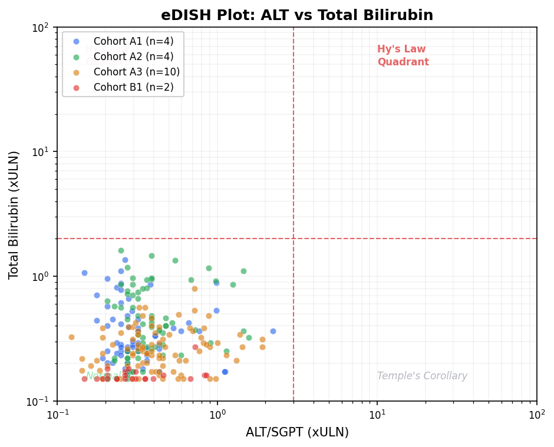

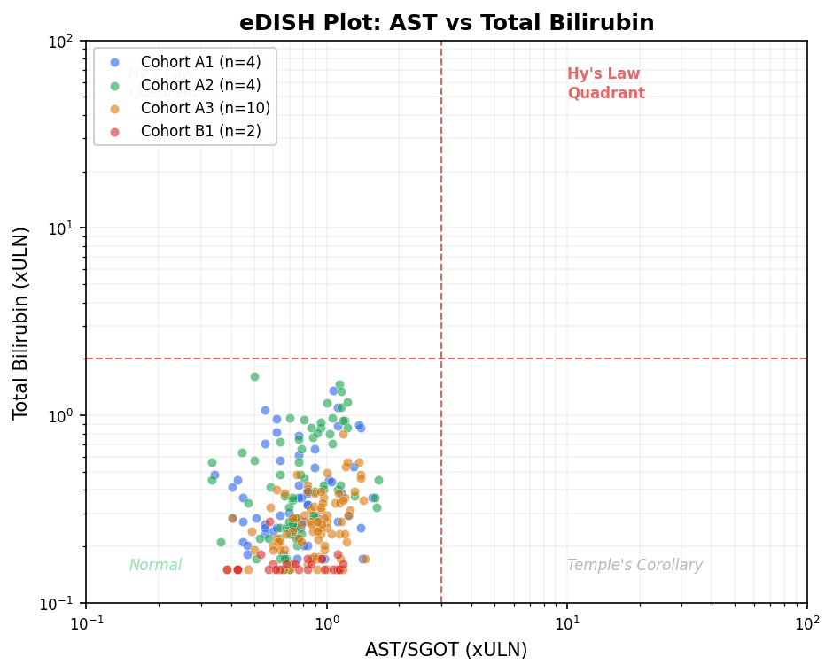

**No participants in Hy's law quadrant (ALT/AST >3×ULN AND TBili >2×ULN) as of data cut 2026-03-20.** Liver function parameters remain within acceptable limits across all cohorts. ALT plot: 242 data points; AST plot: 242 data points.

### 6.6 Lab Outlier Table (>2×ULN or Flagged)

| Subject | Cohort | Visit | Date | Test | Result | Unit | Ref Range | xULN | Flag |
| --- | --- | --- | --- | --- | --- | --- | --- | --- | --- |
| 0016-9001 | A1 | Screening | 2024-01-08 | AST/SGOT | 64 | U/L | 10.0-47.0 | 1.36 | HIGH |
| 0016-9001 | A1 | Screening | 2024-01-08 | Erythrocytes | 5.2 | /pL | 3.9-5.0 | 1.04 | HIGH |
| 0016-9001 | A1 | Screening | 2024-01-08 | Hematocrit | 0.41 | L/L | 0.31-0.38 | 1.08 | HIGH |
| 0016-9001 | A1 | Screening | 2024-01-08 | Hemoglobin | 13.6 | g/dL | 10.2-12.7 | 1.07 | HIGH |
| 0016-9001 | A1 | Screening | 2024-01-08 | LDL-Cholesterol | 3.81 | mmol/L | 0.0-3.36 | 1.13 | HIGH |
| 0016-9001 | A1 | Screening | 2024-01-08 | Uric acid | 303 | umol/L | 130.0-280.0 | 1.08 | HIGH |
| 0016-9001 | A1 | Baseline | 2024-02-01 | AST/SGOT | 61 | U/L | 10.0-47.0 | 1.30 | HIGH |
| 0016-9001 | A1 | Baseline | 2024-02-01 | Hematocrit | 0.39 | L/L | 0.31-0.38 | 1.03 | HIGH |
| 0016-9001 | A1 | Baseline | 2024-02-01 | Hemoglobin | 13.2 | g/dL | 10.2-12.7 | 1.04 | HIGH |
| 0016-9001 | A1 | Baseline | 2024-02-01 | Iron | 48 | ug/dL | 59.0-158.0 | 0.30 | LOW |
| 0016-9001 | A1 | Week 3 | 2024-02-27 | AST/SGOT | 65 | U/L | 10.0-47.0 | 1.38 | HIGH |
| 0016-9001 | A1 | Week 3 | 2024-02-27 | Bicarbonate | 20.5 | mmol/L | 22.0-29.0 | 0.71 | LOW |
| 0016-9001 | A1 | Unscheduled Visit | 2024-02-27 | C4 levels | 4 | mg/dL | 10.0-40.0 | 0.10 | LOW |
| 0016-9001 | A1 | Unscheduled Visit | 2024-02-27 | Circulating Immune Complex Panel: C3 Fragments | 31.9 | ug Eq/mL | 0.0-15.0 | 2.13 | HIGH |
| 0016-9001 | A1 | Week 3 | 2024-02-27 | Creatine kinase | 182 | U/L | 18.0-158.0 | 1.15 | HIGH |
| 0016-9001 | A1 | Week 3 | 2024-02-27 | Eosinophils | 4.2 | % | 0.0-4.1 | 1.02 | HIGH |
| 0016-9001 | A1 | Week 5 | 2024-03-13 | ALT/SGPT | 17 | U/L | 24.0-68.0 | 0.25 | LOW |
| 0016-9001 | A1 | Week 5 | 2024-03-13 | AST/SGOT | 52 | U/L | 10.0-47.0 | 1.11 | HIGH |
| 0016-9001 | A1 | Week 5 | 2024-03-13 | Reticulocyte count | 1.7 | % | 0.1-1.5 | 1.13 | HIGH |
| 0016-9001 | A1 | Week 5 | 2024-03-13 | Reticulocyte count; Absolute | 82 | /nL | 36.0-68.0 | 1.21 | HIGH |
| 0016-9001 | A1 | Week 5 | 2024-03-13 | Total Bilirubin | 1.10 | mg/dL | 0.0-0.99 | 1.11 | HIGH |
| 0016-9001 | A1 | Week 9 | 2024-04-10 | ALT/SGPT | 17 | U/L | 24.0-68.0 | 0.25 | LOW |
| 0016-9001 | A1 | Week 9 | 2024-04-10 | AST/SGOT | 52 | U/L | 10.0-47.0 | 1.11 | HIGH |
| 0016-9001 | A1 | Week 9 | 2024-04-10 | Bicarbonate | 21.1 | mmol/L | 22.0-29.0 | 0.73 | LOW |
| 0016-9001 | A1 | Week 9 | 2024-04-10 | Eosinophils; Absolute Units | 0.02 | /nL | 0.03-0.53 | 0.04 | LOW |
| 0016-9001 | A1 | Unscheduled Visit | 2024-04-24 | C3 levels | 86 | mg/dL | 90.0-180.0 | 0.48 | LOW |
| 0016-9001 | A1 | Unscheduled Visit | 2024-04-24 | C4 levels | <2 | mg/dL | 10.0-40.0 | 0.05 | LOW |
| 0016-9001 | A1 | Week 13 | 2024-05-06 | ALT/SGPT | 18 | U/L | 24.0-68.0 | 0.26 | LOW |
| 0016-9001 | A1 | Week 13 | 2024-05-06 | AST/SGOT | 50 | U/L | 10.0-47.0 | 1.06 | HIGH |
| 0016-9001 | A1 | Week 13 | 2024-05-06 | Bicarbonate | 17.5 | mmol/L | 22.0-29.0 | 0.60 | LOW |

[output cut: 2629 more lines]

### 6.7 Safety Margin Summary

| Parameter | Threshold | Subjects Exceeding | Max xULN (Cohort) | Clinical Note |
| --- | --- | --- | --- | --- |
| ALT/SGPT | >3×ULN | 0/20 | 2.23 (A1) | Within acceptable limits across all cohorts |
| AST/SGOT | >3×ULN | 0/20 | 1.64 (A2) | Within acceptable limits across all cohorts |
| Total Bilirubin | >1.5×ULN | 1/20 | 1.63 (A2) | Exceeded in: 2064-9002 |
| Direct Bilirubin | >1.5×ULN | 0/20 | 1.31 (A2) | Within acceptable limits across all cohorts |
| Alkaline Phosphatase | >1.5×ULN | 1/20 | 1.84 (B1) | Exceeded in: 0017-9004 |
| Creatinine | >1.5×ULN | 0/20 | 0.96 (A1) | Within acceptable limits across all cohorts |
| Creatine kinase | >5×ULN | 0/20 | 1.43 (B1) | Within acceptable limits across all cohorts |

## 7. ECG Summary

**Note:** ECG analysis requires ECG SAS data (`eg1.sas7bdat`) which is not available from CSV extract. ECG data includes QTcF, PR interval, QRS duration, and HR assessments.

| Parameter | Visit | N | Mean | SD | Min | Max |
| --- | --- | --- | --- | --- | --- | --- |
| Data pending - requires eg1.sas7bdat |  |  |  |  |  |  |

## 8. Vital Signs

**Note:** Vital signs analysis requires VS SAS data (`vs.sas7bdat`) which is not available from CSV extract. Vital signs data includes systolic/diastolic BP, heart rate, respiratory rate, temperature, and weight.

| Parameter | Visit | N | Mean | SD | Min | Max |
| --- | --- | --- | --- | --- | --- | --- |
| Data pending - requires vs.sas7bdat |  |  |  |  |  |  |

## Appendix: Data Changes Tracker

## Data Changes: 2026FEB24 → 2026MAR20

DELTA Lab records: 11,698 → 12,216 (+518)

NEW Subjects in lab data: None

NEW Visits: ITI Baseline, ITI W2D13, Week 109

### Record Count Changes by Test Category

| Category | Previous | Current | Delta |
| --- | --- | --- | --- |
| Biochemistry | 5,344 | 5,542 | +198 |
| Hematology | 4,873 | 5,104 | +231 |
| Immune Response Biomarker | 462 | 477 | +15 |
| Immunoglobulin level | 4 | 4 | +0 |
| Iron Panel | 332 | 344 | +12 |
| Lymphocyte subsets | 0 | 2 | +2 |
| Pregnancy test | 12 | 12 | +0 |
| Urine Chemistry | 671 | 731 | +60 |

DNLI-I-0001 MMR · March 2026 · Safety-Focused Report Generated 2026-04-12 09:50 · Confidential